# Data visualization: live R demonstration

POLI 210 - Seminar 9 - October 28, 2026

Author

Brad LeVeck

Open `poli210-seminar9.Rproj`, then this file. Run from the top or render in a fresh session. The bundled data are the same selected election extract used last week, plus a carefully checked election-to-member match.

## 1. Setup and the unit of observation

Install `dplyr`, `tidyr`, `readr`, and `ggplot2` once if needed. Load them each session. The setup script below reads the local CSVs, creates the subsets, and sets colors.

```r
source("R/setup.R")
elections |> count(year)
```

```
# A tibble: 28 × 2
    year     n
   <dbl> <int>
 1  1946   328
 2  1948   319
 3  1950   315
 4  1954   316
 5  1956   332
 6  1958   325
 7  1960   324
 8  1964   353
 9  1966   349
10  1968   342
# ℹ 18 more rows
```

```r
glimpse(e2014)
```

```
Rows: 328
Columns: 11
$ source_row <dbl> 9010, 9011, 9012, 9013, 9014, 9015, 9016, 9017, 9018, 9019,…
$ year       <dbl> 2014, 2014, 2014, 2014, 2014, 2014, 2014, 2014, 2014, 2014,…
$ stcd       <dbl> 102, 103, 106, 201, 301, 302, 303, 304, 305, 306, 309, 401,…
$ ptynow     <dbl> -1, -1, -1, -1, 1, 1, 1, -1, -1, -1, 1, -1, -1, -1, -1, 1, …
$ inc3       <dbl> -1, -1, 0, -1, 1, 1, 1, -1, -1, -1, 1, -1, 0, 0, -1, 1, 1, …
$ dv         <dbl> 32.6, 33.8, 23.7, 44.6, 52.6, 50.0, 55.8, 26.9, 30.4, 35.1,…
$ dvp        <dbl> 36.3, 35.9, 28.7, 30.9, 51.9, 50.4, 61.1, 29.8, 32.8, 35.2,…
$ state      <dbl> 1, 1, 1, 2, 3, 3, 3, 3, 3, 3, 3, 4, 4, 4, 5, 5, 5, 5, 5, 5,…
$ south      <dbl> 1, 1, 1, 0, 0, 0, 0, 0, 0, 0, 0, 1, 1, 1, 0, 0, 0, 0, 0, 0,…
$ dpres      <dbl> 36.66, 37.13, 24.95, 42.69, 48.73, 49.24, 62.46, 31.57, 35.…
$ incumbent  <fct> Republican, Republican, Open seat, Republican, Democratic, …
```

`elections`: one retained district-election. `dv`, `dvp`, and `dpres` are percentages (0–100), not proportions (0–1). `dvp` is prior House vote; `dpres` is current or most recent presidential vote. There are 328 retained 2014 races, not a census of 435 districts. An unweighted district mean is not the national popular vote.

## 2. The first scatterplot

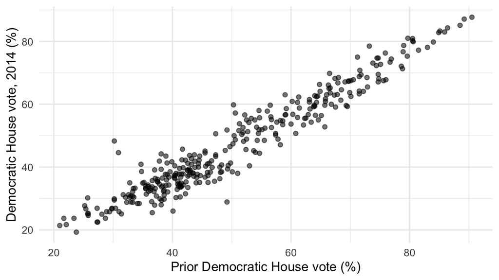

```r
p <- ggplot(e2014, aes(x = dvp, y = dv)) +
  geom_point(alpha = 0.55) +
  labs(x = "Prior Democratic House vote (%)",
       y = "Democratic House vote, 2014 (%)")
p
```

Try adding an equality line. The added layer does not change the saved `p` unless you assign the result back to `p`.

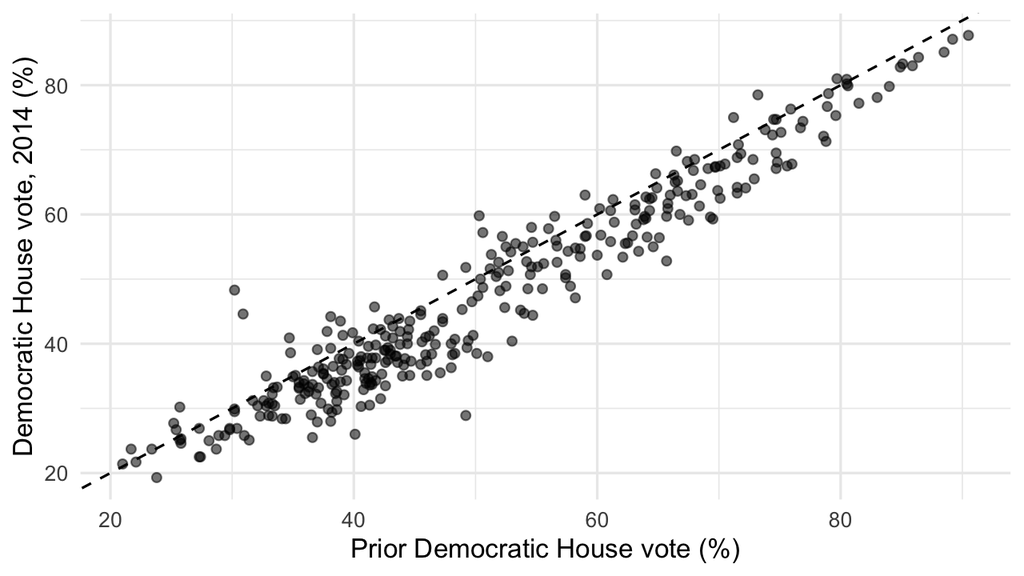

```r
p + geom_abline(intercept = 0, slope = 1, linetype = 2)
```

## 3. Map a variable; set a constant

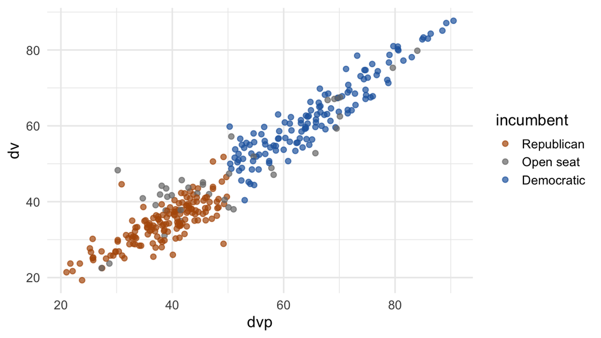

```r
ggplot(e2014, aes(dvp, dv)) +
  geom_point(aes(color = incumbent), alpha = 0.7) +
  scale_color_manual(values = inc_colors)
```

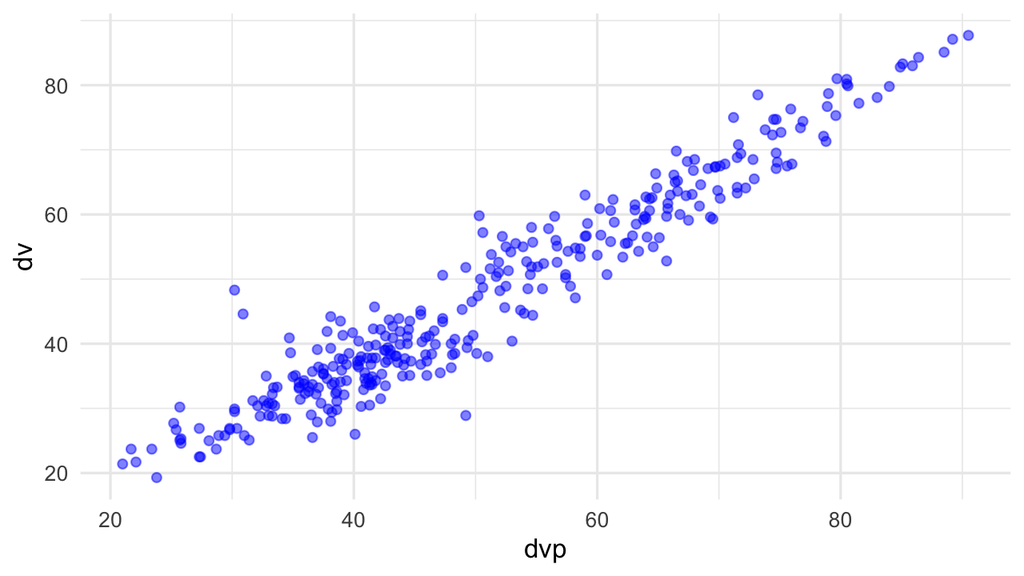

```r
ggplot(e2014, aes(dvp, dv)) + geom_point(color = "blue", alpha = 0.5)
```

Try `aes(color = "blue")`. It creates a category named “blue”; it does not instruct ggplot to use the literal color blue.

## 4. Global mappings versus layer mappings

Color in the point layer: **one** fitted line.

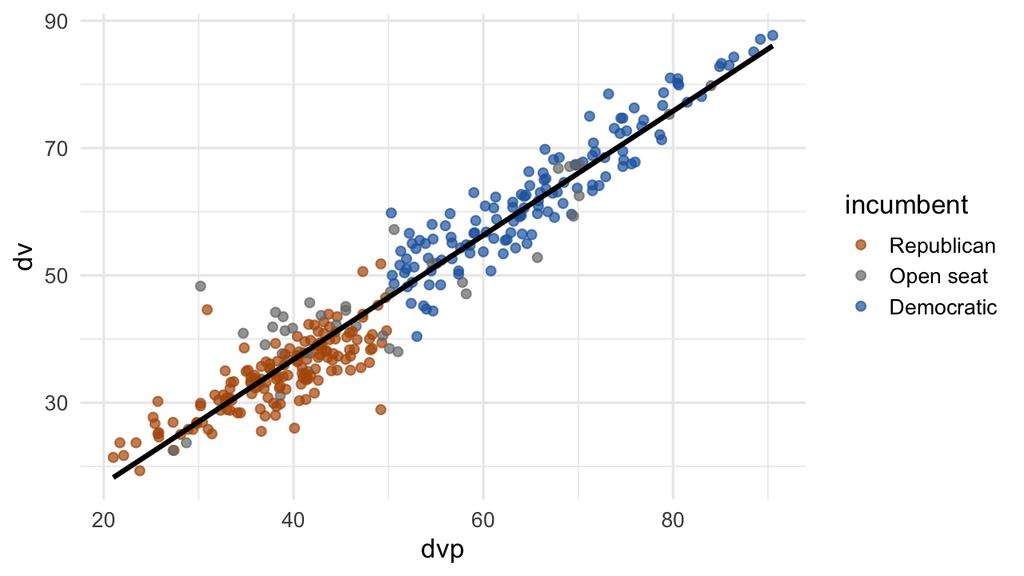

```r
ggplot(e2014, aes(dvp, dv)) +
  geom_point(aes(color = incumbent), alpha = 0.7) +
  geom_smooth(method = "lm", formula = y ~ x, se = FALSE, color = "black") +
  scale_color_manual(values = inc_colors)
```

Color in the global mapping: **separate** fitted lines for the incumbent categories. This is an exercise in grouping, not a causal model of incumbency.

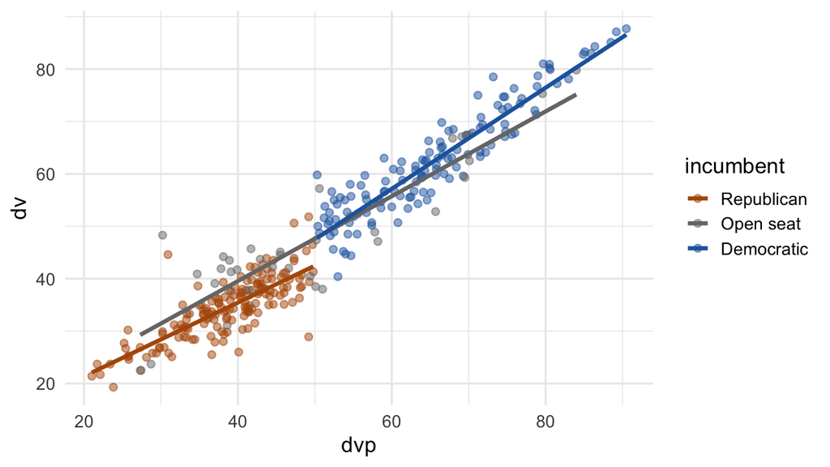

```r
ggplot(e2014, aes(dvp, dv, color = incumbent)) +
  geom_point(alpha = 0.5) +
  geom_smooth(method = "lm", formula = y ~ x, se = FALSE) +
  scale_color_manual(values = inc_colors)
```

## 5. Facet by election

The last five years in the extract are 2004, 2006, 2008, 2010, and 2014. Keep the same axis scales to make comparisons meaningful.

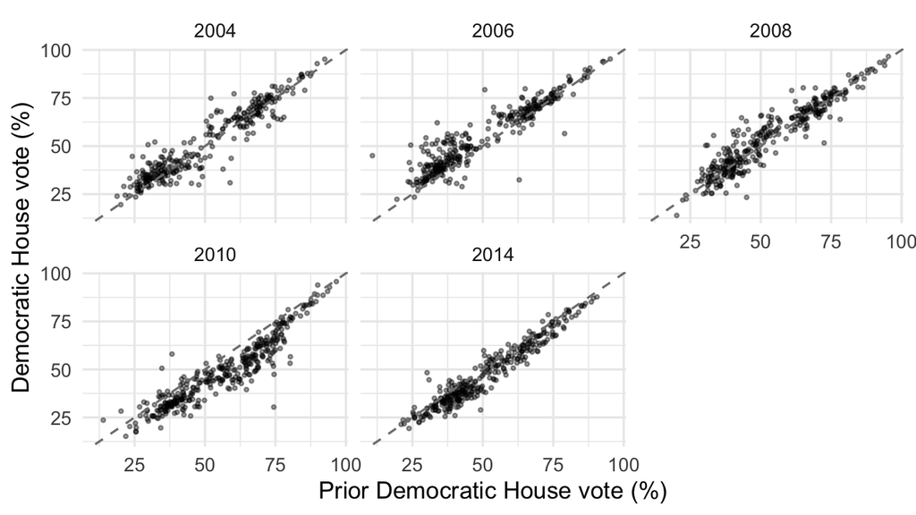

```r
ggplot(recent, aes(dvp, dv)) +
  geom_point(alpha = 0.4, size = 0.8) +
  geom_abline(slope = 1, intercept = 0, linetype = 2, color = "grey50") +
  facet_wrap(~year, nrow = 2) +
  labs(x = "Prior Democratic House vote (%)", y = "Democratic House vote (%)")
```

## 6. Presidential vote and a continuous color scale

First, all rows with observed presidential vote:

```r
nrow(pres)
```

```
[1] 8212
```

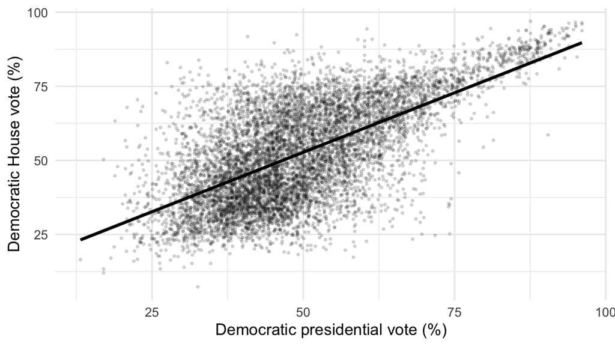

```r
ggplot(pres, aes(dpres, dv)) +
  geom_point(alpha = 0.14, size = 0.7) +
  geom_smooth(method = "lm", formula = y ~ x, se = FALSE, color = "black") +
  labs(x = "Democratic presidential vote (%)", y = "Democratic House vote (%)")
```

The prepared match links each election to its following Congress, by state and district. Multiple-member keys and unmatched keys are not guessed. The match never duplicates an election row. See `SOURCES.txt` for construction details.

```r
linked |> count(match_status)
```

```
# A tibble: 3 × 2
  match_status                n
  <chr>                   <int>
1 Matched                  9149
2 Multiple member records   167
3 No exact district key      21
```

```r
nrow(matched)  # Unique member matches with observed dpres
```

```
[1] 8061
```

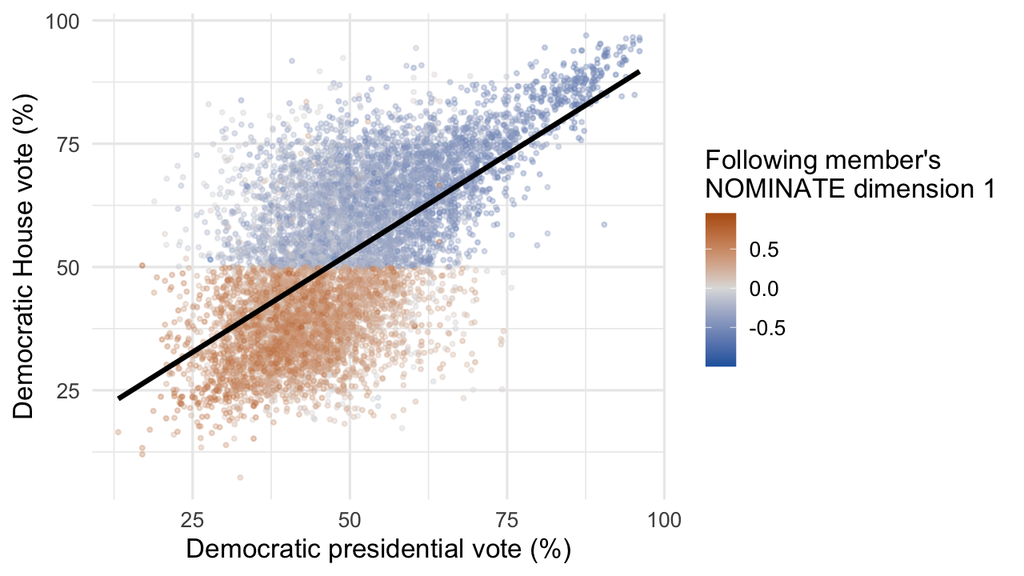

```r
p_ideology <- ggplot(matched, aes(dpres, dv)) +
  geom_point(aes(color = nominate_dim1), alpha = 0.35, size = 0.8) +
  geom_smooth(method = "lm", formula = y ~ x, se = FALSE, color = "black") +
  scale_color_gradient2(low = "#2166ac", mid = "#dedede", high = "#b35806",
                        midpoint = 0) +
  labs(x = "Democratic presidential vote (%)", y = "Democratic House vote (%)",
       color = "Following member's\nNOMINATE dimension 1")
p_ideology
```

The score describes the member, not the electorate; it is not a pre-election predictor. The black line is pooled, not fitted conditional on the score. For a clearer view of observations, rebuild with 2014 only:

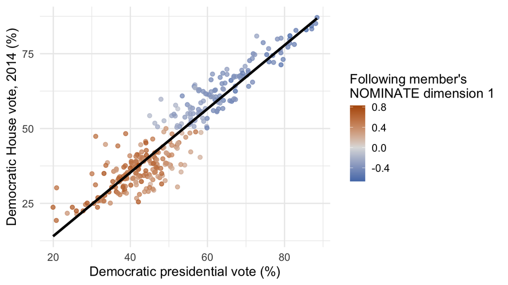

```r
matched2014 <- matched |> filter(year == 2014)
ggplot(matched2014, aes(dpres, dv)) +
  geom_point(aes(color = nominate_dim1), alpha = 0.75, size = 1.8) +
  geom_smooth(method = "lm", formula = y ~ x, se = FALSE, color = "black") +
  scale_color_gradient2(low = "#2166ac", mid = "#dedede", high = "#b35806",
                        midpoint = 0) +
  labs(x = "Democratic presidential vote (%)", y = "Democratic House vote, 2014 (%)",
       color = "Following member's\nNOMINATE dimension 1")
```

## 7. Histograms and category counts

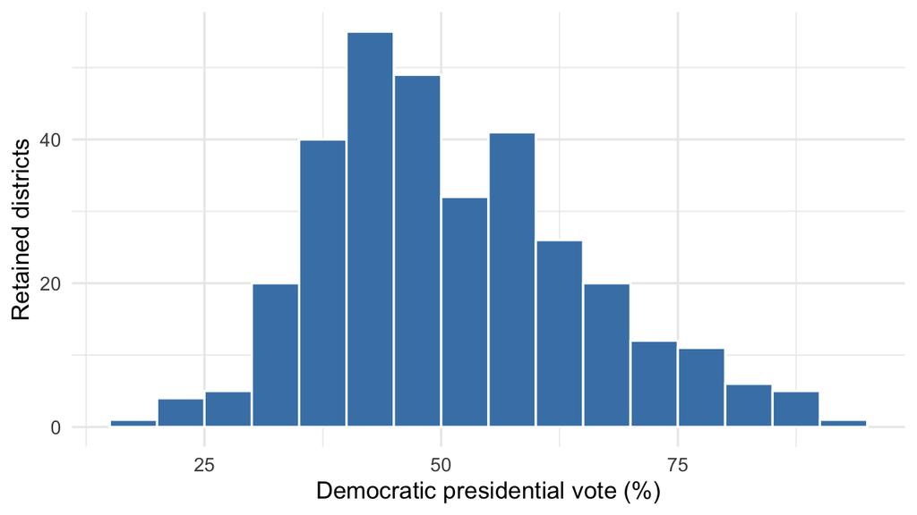

```r
ggplot(e2014, aes(dpres)) +
  geom_histogram(binwidth = 5, boundary = 0, fill = "steelblue", color = "white") +
  labs(x = "Democratic presidential vote (%)", y = "Retained districts")
```

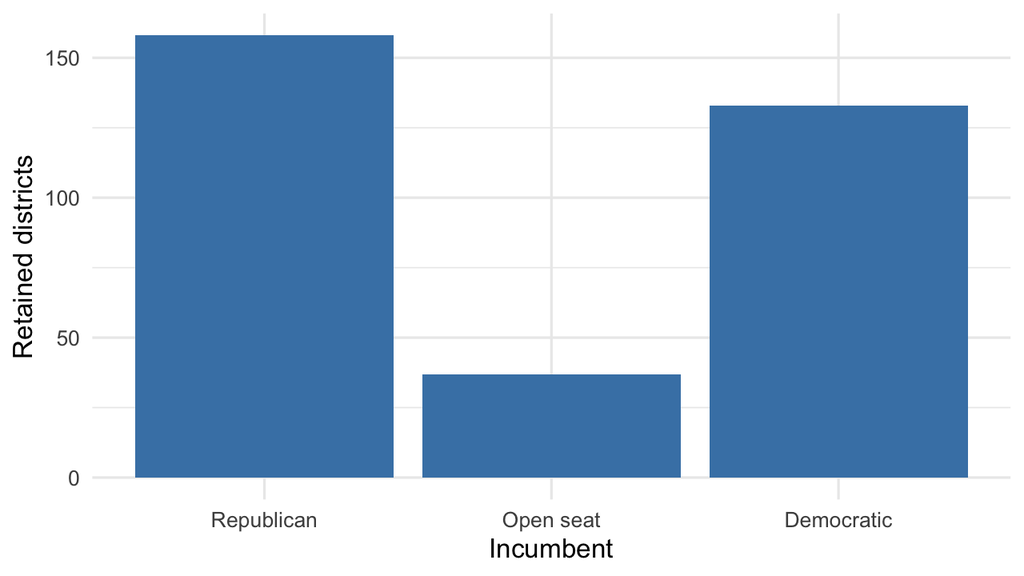

```r
ggplot(e2014, aes(incumbent)) + geom_bar(fill = "steelblue") +
  labs(x = "Incumbent", y = "Retained districts")
```

Try histogram widths 2 and 10. For a density scale, use `aes(dpres, y = after_stat(density))`. With unequal bin widths, area rather than raw height is especially important. Our examples use equal-width bins.

## 8. From summarise to ggplot

First make a small dataset with one row per group. Print it before plotting.

```r
means <- e2014 |>
  group_by(incumbent) |>
  summarise(mean_dv = mean(dv), sd_dv = sd(dv), n = n(),
            sem = sd_dv / sqrt(n), .groups = "drop")
knitr::kable(means, digits = 2)
```

| incumbent | mean_dv | sd_dv | n | sem |
| --- | --- | --- | --- | --- |
| Republican | 34.40 | 5.78 | 158 | 0.46 |
| Open seat | 47.56 | 13.16 | 37 | 2.16 |
| Democratic | 62.31 | 10.28 | 133 | 0.89 |

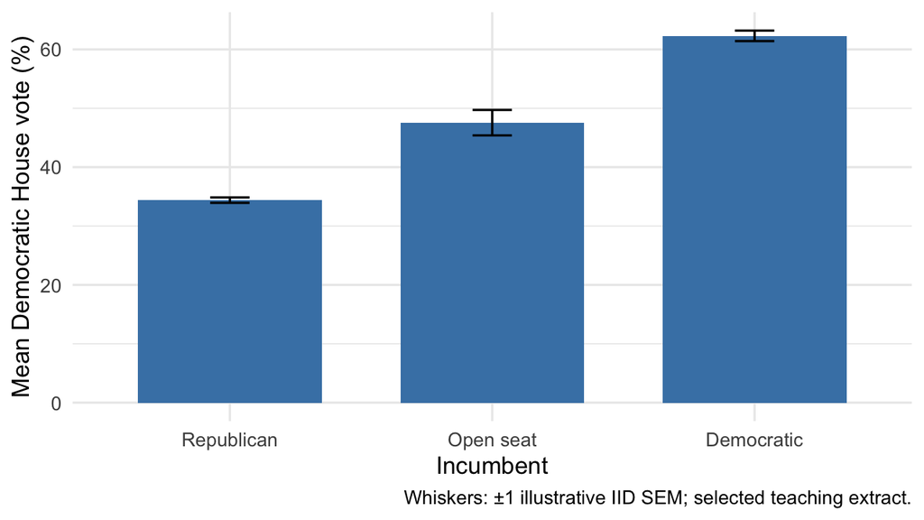

```r
ggplot(means, aes(incumbent, mean_dv)) +
  geom_col(fill = "steelblue", width = 0.7) +
  geom_errorbar(aes(ymin = mean_dv - sem, ymax = mean_dv + sem), width = 0.15) +
  labs(x = "Incumbent", y = "Mean Democratic House vote (%)",
       caption = "Whiskers: ±1 illustrative IID SEM; selected teaching extract.")
```

`sd_dv` measures variation across districts. `sem` is the standard error of the mean **under IID sampling assumptions**. The extract is not a random sample, so these are an illustration of the plotting workflow, not justified national-election uncertainty statements. A small whisker does not remove selection bias. With missing values, filter the relevant outcome first so the mean, SD, and denominator use the same observations.

## 9. Reshape, summarise, then draw grouped bars

```r
vote_long <- e2014 |>
  select(incumbent, dv, dvp) |>
  pivot_longer(c(dv, dvp), names_to = "election", values_to = "vote") |>
  mutate(election = factor(election, levels = c("dvp", "dv"),
                            labels = c("Prior", "2014")))
head(vote_long)
```

```
# A tibble: 6 × 3
  incumbent  election  vote
  <fct>      <fct>    <dbl>
1 Republican 2014      32.6
2 Republican Prior     36.3
3 Republican 2014      33.8
4 Republican Prior     35.9
5 Open seat  2014      23.7
6 Open seat  Prior     28.7
```

```r
vote_summary <- vote_long |>
  filter(!is.na(vote)) |>
  group_by(incumbent, election) |>
  summarise(mean_vote = mean(vote), n = n(),
            sem = sd(vote) / sqrt(n()), .groups = "drop")
knitr::kable(vote_summary, digits = 2)
```

| incumbent | election | mean_vote | n | sem |
| --- | --- | --- | --- | --- |
| Republican | Prior | 38.51 | 158 | 0.52 |
| Republican | 2014 | 34.40 | 158 | 0.46 |
| Open seat | Prior | 49.90 | 37 | 2.40 |
| Open seat | 2014 | 47.56 | 37 | 2.16 |
| Democratic | Prior | 65.35 | 133 | 0.86 |
| Democratic | 2014 | 62.31 | 133 | 0.89 |

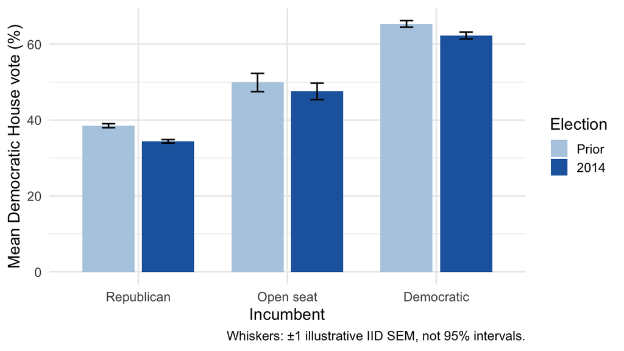

```r
dodge <- position_dodge(width = 0.8)
p_grouped <- ggplot(vote_summary, aes(incumbent, mean_vote, fill = election)) +
  geom_col(position = dodge, width = 0.7) +
  geom_errorbar(aes(ymin = mean_vote - sem, ymax = mean_vote + sem),
                position = dodge, width = 0.18) +
  scale_fill_manual(values = c(Prior = "#b3cde3", `2014` = "#2166ac")) +
  labs(x = "Incumbent", y = "Mean Democratic House vote (%)", fill = "Election",
       caption = "Whiskers: ±1 illustrative IID SEM, not 95% intervals.")
p_grouped
```

The same district appears at two times; those are not independent samples. Do not infer a test of change by looking at overlap of these whiskers. The exercise is how to turn group summaries and endpoints into aligned layers.

## 10. Boxplots show observations’ distributions

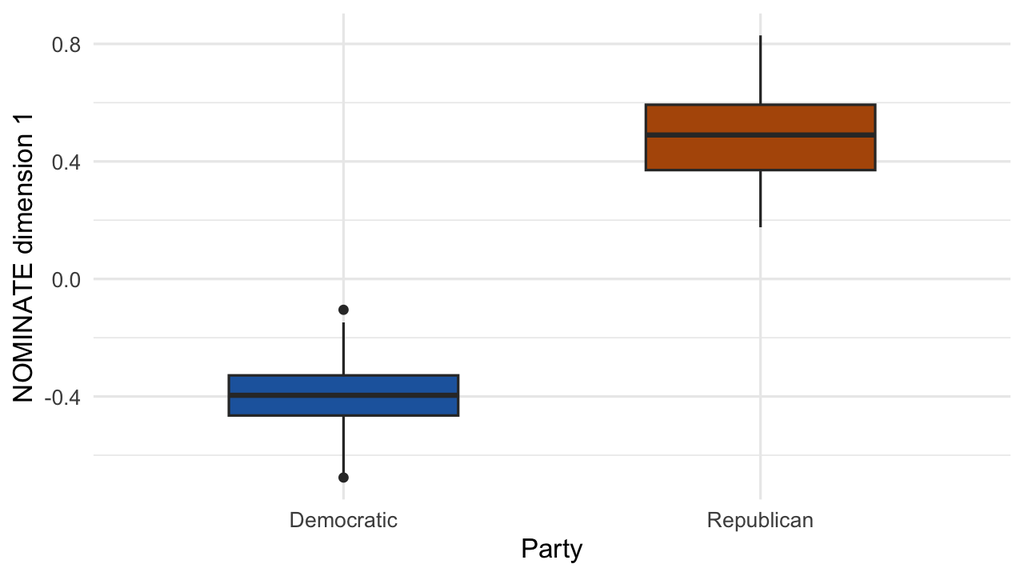

```r
ggplot(house, aes(party, nominate_dim1, fill = party)) +
  geom_boxplot(width = 0.55) +
  scale_fill_manual(values = party_colors, guide = "none") +
  labs(x = "Party", y = "NOMINATE dimension 1")
```

Box: middle 50%; line: median; whiskers: observations within 1.5 IQR of box edges. Outside points are not automatically mistakes. This is not an interval for the mean. Optional: add `geom_jitter(width = 0.08, height = 0, alpha = 0.2)` (and set `outlier.shape = NA` in the box layer to avoid duplicate outlier points).

## 11. Plotting supplied model tables

Here we supply an ordinary table of fitted values and endpoints from a descriptive election model. The preparation is provided; regression is not today’s learning objective. B4 supplies analogous robust-regression tables.

```r
fit <- lm(dv ~ dpres, data = e2014)
grid <- data.frame(dpres = seq(min(e2014$dpres, na.rm = TRUE),
                              max(e2014$dpres, na.rm = TRUE), length.out = 100))
predictions <- bind_cols(grid, as.data.frame(predict(fit, newdata = grid,
                                                     interval = "confidence")))
head(predictions)
```

```
     dpres      fit      lwr      upr
1 19.94000 14.02845 12.49363 15.56327
2 20.65727 14.78832 13.28282 16.29381
3 21.37455 15.54819 14.07190 17.02447
4 22.09182 16.30805 14.86085 17.75526
5 22.80909 17.06792 15.64966 18.48617
6 23.52636 17.82778 16.43834 19.21723
```

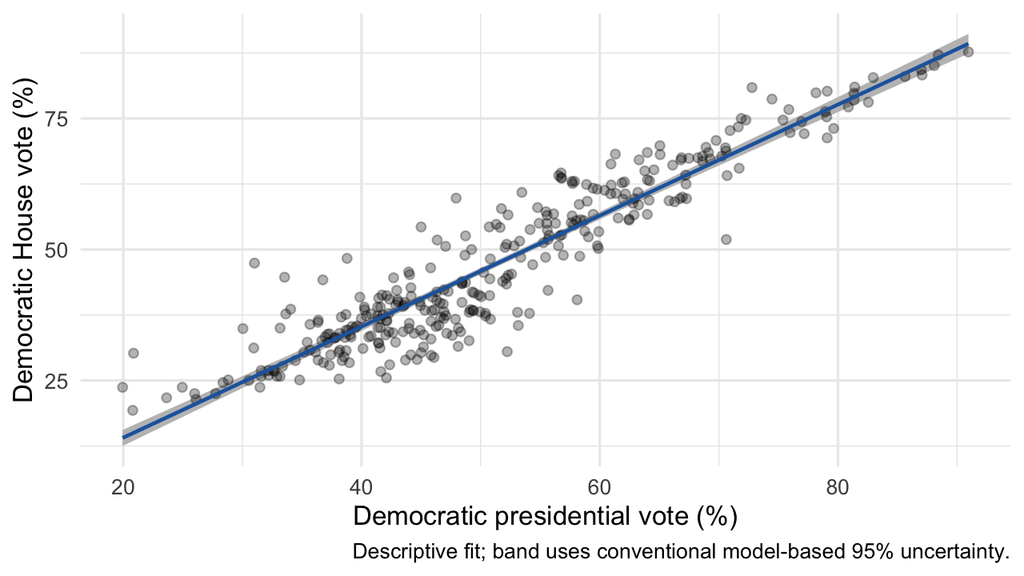

```r
ggplot() +
  geom_ribbon(data = predictions,
    aes(x = dpres, ymin = lwr, ymax = upr), fill = "grey75") +
  geom_point(data = e2014, aes(dpres, dv), alpha = 0.3) +
  geom_line(data = predictions, aes(dpres, fit), color = "#2166ac", linewidth = 1) +
  labs(x = "Democratic presidential vote (%)", y = "Democratic House vote (%)",
       caption = "Descriptive fit; band uses conventional model-based 95% uncertainty.")
```

Different layers use different tables. The grid’s rows are not extra districts. The band concerns the fitted mean, not the spread of individual outcomes. Its interpretation depends on model/sampling assumptions.

## 12. Save and render

```r
ggsave("grouped-vote.png", plot = p_grouped, width = 7, height = 4.5, dpi = 300)
```

This optional command writes a standalone image to the project folder. The plot is already embedded in the rendered HTML. Restart R and render to verify that the report does not depend on objects left in the Console.

## Optional: Normal Q–Q plots

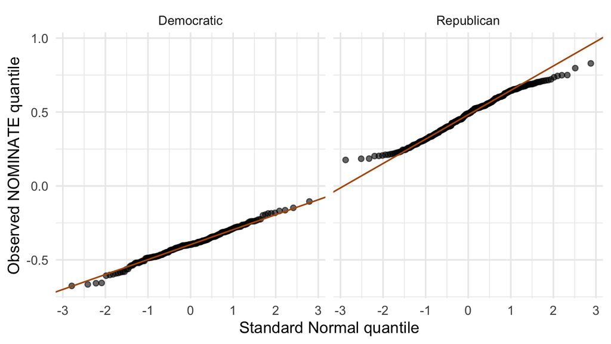

```r
ggplot(house, aes(sample = nominate_dim1)) +
  stat_qq(alpha = 0.6) +
  stat_qq_line(color = "#b35806") +
  facet_wrap(~party) +
  labs(x = "Standard Normal quantile", y = "Observed NOMINATE quantile")
```

At matching cumulative probabilities, compare an observed score with a Normal quantile. Approximate straightness is compatible with a Normal shape; it does not require a zero mean or unit SD. The reference line uses the first and third quartiles. Departures are diagnostic, not an automatic hypothesis test. A variable’s distribution is not its mean’s sampling distribution.

Sources and match construction: `SOURCES.txt`. Reading: [PSD Chapter 7](https://probstatsdata.com/ggplotviz.html).